# Red Wine Qulaity Exploration by Prateek

## Loading essential packages

```r
library(gridExtra)
library(ggplot2)
library(reshape2)
```

## Loading data set and checking the snapshot of data varibale and values.

```r
winedata = read.csv("C:/Users/prateek/Desktop/wineQualityReds.csv")
head(winedata)
```

```
##   X fixed.acidity volatile.acidity citric.acid residual.sugar chlorides
## 1 1           7.4             0.70        0.00            1.9     0.076
## 2 2           7.8             0.88        0.00            2.6     0.098
## 3 3           7.8             0.76        0.04            2.3     0.092
## 4 4          11.2             0.28        0.56            1.9     0.075
## 5 5           7.4             0.70        0.00            1.9     0.076
## 6 6           7.4             0.66        0.00            1.8     0.075
##   free.sulfur.dioxide total.sulfur.dioxide density   pH sulphates alcohol
## 1                  11                   34  0.9978 3.51      0.56     9.4
## 2                  25                   67  0.9968 3.20      0.68     9.8
## 3                  15                   54  0.9970 3.26      0.65     9.8
## 4                  17                   60  0.9980 3.16      0.58     9.8
## 5                  11                   34  0.9978 3.51      0.56     9.4
## 6                  13                   40  0.9978 3.51      0.56     9.4
##   quality
## 1       5
## 2       5
## 3       5
## 4       6
## 5       5
## 6       5
```

# Statiscal Summary

## Structure of data

```r
str(winedata)
```

```
## 'data.frame':    1599 obs. of  13 variables:
##  $ X                   : int  1 2 3 4 5 6 7 8 9 10 ...
##  $ fixed.acidity       : num  7.4 7.8 7.8 11.2 7.4 7.4 7.9 7.3 7.8 7.5 ...
##  $ volatile.acidity    : num  0.7 0.88 0.76 0.28 0.7 0.66 0.6 0.65 0.58 0.5 ...
##  $ citric.acid         : num  0 0 0.04 0.56 0 0 0.06 0 0.02 0.36 ...
##  $ residual.sugar      : num  1.9 2.6 2.3 1.9 1.9 1.8 1.6 1.2 2 6.1 ...
##  $ chlorides           : num  0.076 0.098 0.092 0.075 0.076 0.075 0.069 0.065 0.073 0.071 ...
##  $ free.sulfur.dioxide : num  11 25 15 17 11 13 15 15 9 17 ...
##  $ total.sulfur.dioxide: num  34 67 54 60 34 40 59 21 18 102 ...
##  $ density             : num  0.998 0.997 0.997 0.998 0.998 ...
##  $ pH                  : num  3.51 3.2 3.26 3.16 3.51 3.51 3.3 3.39 3.36 3.35 ...
##  $ sulphates           : num  0.56 0.68 0.65 0.58 0.56 0.56 0.46 0.47 0.57 0.8 ...
##  $ alcohol             : num  9.4 9.8 9.8 9.8 9.4 9.4 9.4 10 9.5 10.5 ...
##  $ quality             : int  5 5 5 6 5 5 5 7 7 5 ...
```

## Statistical summary of the variables

```r
summary(winedata)
```

```
##        X          fixed.acidity   volatile.acidity  citric.acid
##  Min.   :   1.0   Min.   : 4.60   Min.   :0.1200   Min.   :0.000
##  1st Qu.: 400.5   1st Qu.: 7.10   1st Qu.:0.3900   1st Qu.:0.090
##  Median : 800.0   Median : 7.90   Median :0.5200   Median :0.260
##  Mean   : 800.0   Mean   : 8.32   Mean   :0.5278   Mean   :0.271
##  3rd Qu.:1199.5   3rd Qu.: 9.20   3rd Qu.:0.6400   3rd Qu.:0.420
##  Max.   :1599.0   Max.   :15.90   Max.   :1.5800   Max.   :1.000
##  residual.sugar     chlorides       free.sulfur.dioxide
##  Min.   : 0.900   Min.   :0.01200   Min.   : 1.00
##  1st Qu.: 1.900   1st Qu.:0.07000   1st Qu.: 7.00
##  Median : 2.200   Median :0.07900   Median :14.00
##  Mean   : 2.539   Mean   :0.08747   Mean   :15.87
##  3rd Qu.: 2.600   3rd Qu.:0.09000   3rd Qu.:21.00
##  Max.   :15.500   Max.   :0.61100   Max.   :72.00
##  total.sulfur.dioxide    density             pH          sulphates
##  Min.   :  6.00       Min.   :0.9901   Min.   :2.740   Min.   :0.3300
##  1st Qu.: 22.00       1st Qu.:0.9956   1st Qu.:3.210   1st Qu.:0.5500
##  Median : 38.00       Median :0.9968   Median :3.310   Median :0.6200
##  Mean   : 46.47       Mean   :0.9967   Mean   :3.311   Mean   :0.6581
##  3rd Qu.: 62.00       3rd Qu.:0.9978   3rd Qu.:3.400   3rd Qu.:0.7300
##  Max.   :289.00       Max.   :1.0037   Max.   :4.010   Max.   :2.0000
##     alcohol         quality
##  Min.   : 8.40   Min.   :3.000
##  1st Qu.: 9.50   1st Qu.:5.000
##  Median :10.20   Median :6.000
##  Mean   :10.42   Mean   :5.636
##  3rd Qu.:11.10   3rd Qu.:6.000
##  Max.   :14.90   Max.   :8.000
```

- There are **1,599** observation with total **13** variables.
- All varibales are numeric except `Quality` and `X`.
- We can get an idea form `quality` varibale that minimum wine quality is 3 and maximum wine qualtity is 8 with a mean value of 5.6.

# Univariate Plots Section

Looking at the distribution of each varibale in my dataset. Here i have looped through each varibale and createda hostograms to look at the distributions of the indiviual varibales.

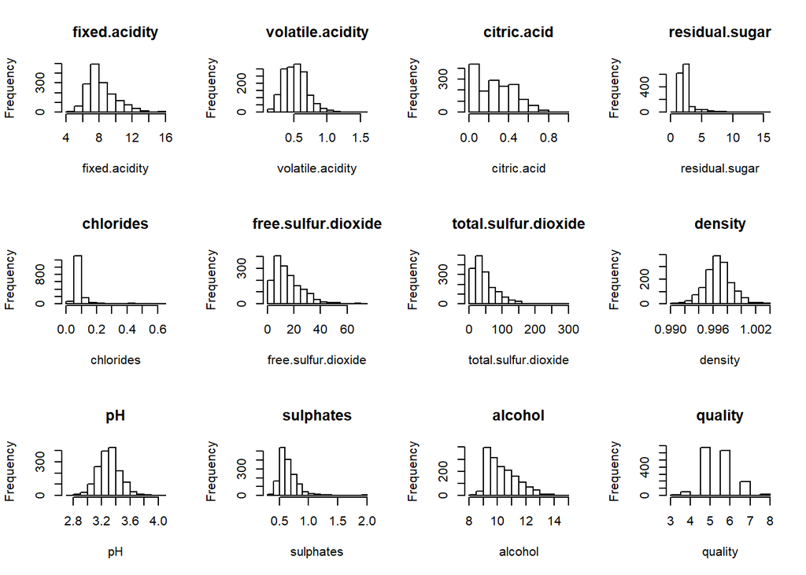

```r
winedatap = winedata[-1]
layout(matrix(c(1,2,3,4,5,6,7,8,9,10,11,12),ncol = 4, nrow =3, byrow = TRUE))
for(i in colnames(winedatap)){
  hist(winedatap[[i]], xlab = i, main = i)}
```

# Univariate Analysis

## Creating New Factor Variable

As we can see the entire wine quality are in the range of 3 to 8 with the most common values are 5 and 6 and the least common values are 3, 4, 7, and 8. So, we create another variable classifing good qualtiy and premium quality wine.

- Good Qulaity Wine = 0
- Premium Quality Wine = 1

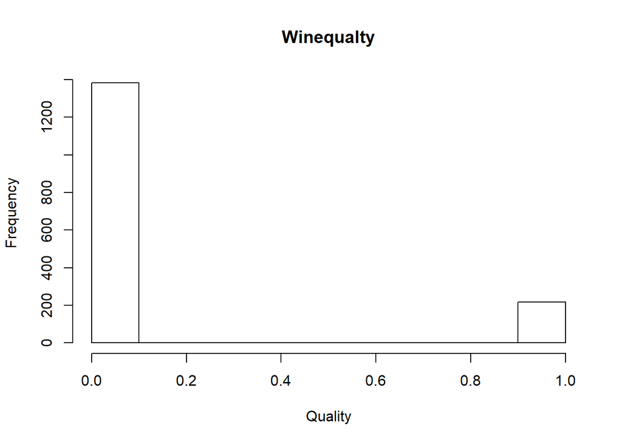

```r
winedatap$winequality = ifelse(winedatap$quality > 6, "1", "0")
winedatap$winequality = as.numeric(winedatap$winequality)
hist(winedatap$winequality, xlab = "Quality", main = "Winequalty")
```

## Checking outliers with the help of box plot

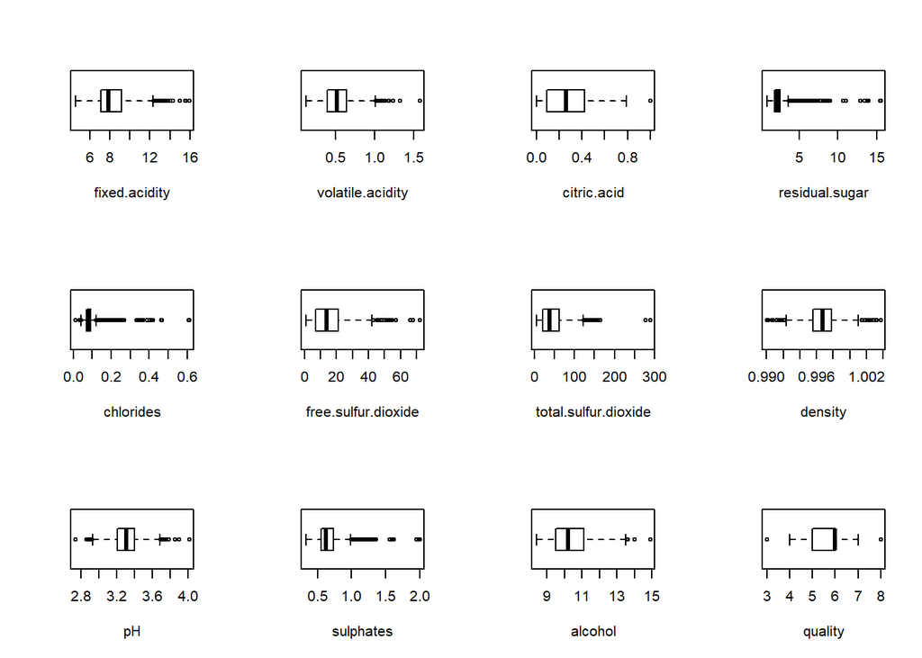

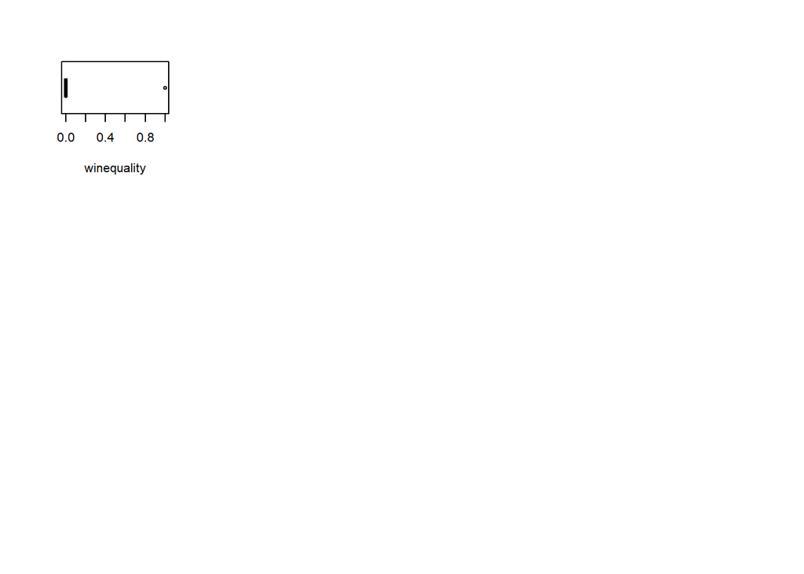

```r
layout(matrix(c(1,2,3,4,5,6,7,8,9,10,11,12),ncol = 4, nrow =3, byrow = TRUE))
for(i in colnames(winedatap)){
  boxplot(winedatap[[i]], horizontal = T, xlab = i)}
```

- `Density` and `pH` are normally distributed with few outliers.
- `Residual.sugar` and `chlorides` have extreme outliers.

## Find some patterns in residual.sugar and chlorides after removing some extreme outliers

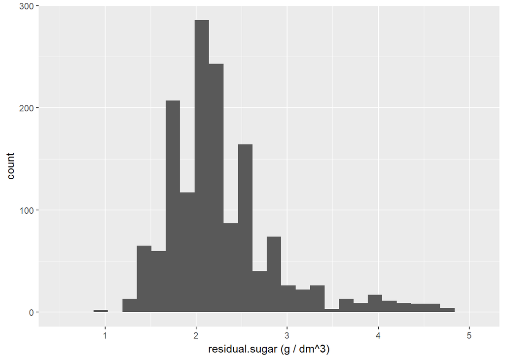

```r
par(mfrow = c(2,2))
ggplot(data = winedatap, aes(x = residual.sugar)) +
  geom_histogram() +
  scale_x_continuous(lim = c(0.5, quantile(winedatap$residual.sugar, 0.95))) +
  xlab('residual.sugar (g / dm^3)')
```

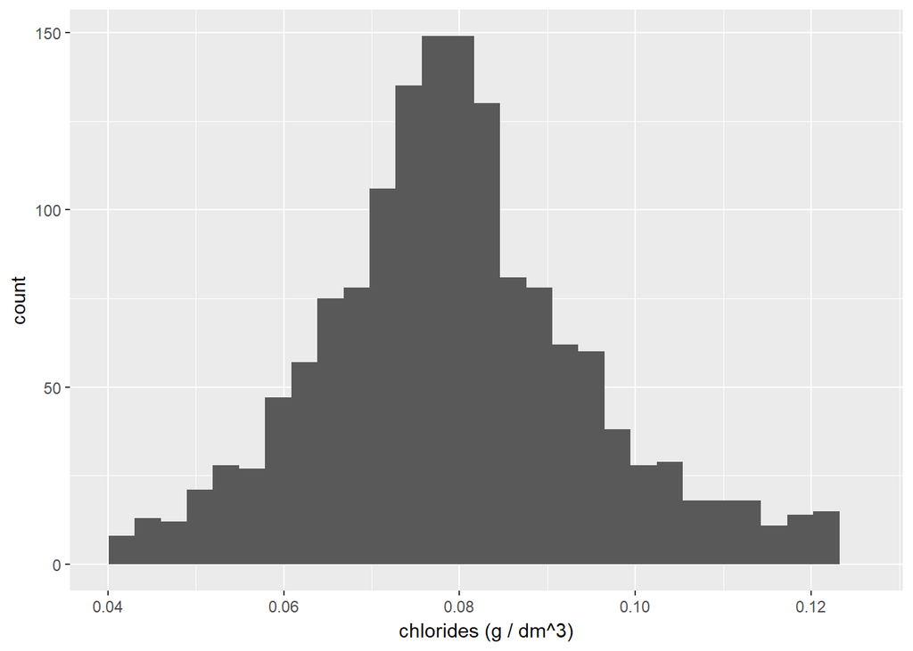

```r
ggplot(data = winedatap, aes(x = chlorides)) +
  geom_histogram() +
  scale_x_continuous(lim = c(0.04, quantile(winedatap$chlorides, 0.95))) +
  xlab('chlorides (g / dm^3)')
```

- After removing some extreme outliers, we see chlorides are now normally distributed

## Check diffirence in mean value for the overall distribution and distribution for premium qulaity wine.

If the diffirence in too high we can get a small idea if that particular varibale helps in creating a premium wine.

```r
goodqualitydata = winedatap[winedatap$quality>6,]
for(i in colnames(winedatap)){
  for(j in colnames(goodqualitydata)){
    a = mean(goodqualitydata[[j]])}
  b = mean(winedatap[[i]])
  print(i)
  print(b-a)
}
```

```
## [1] "fixed.acidity"
## [1] 7.319637
## [1] "volatile.acidity"
## [1] -0.4721795
## [1] "citric.acid"
## [1] -0.7290244
## [1] "residual.sugar"
## [1] 1.538806
## [1] "chlorides"
## [1] -0.9125335
## [1] "free.sulfur.dioxide"
## [1] 14.87492
## [1] "total.sulfur.dioxide"
## [1] 45.46779
## [1] "density"
## [1] -0.003253321
## [1] "pH"
## [1] 2.311113
## [1] "sulphates"
## [1] -0.3418512
## [1] "alcohol"
## [1] 9.422983
## [1] "quality"
## [1] 4.636023
## [1] "winequality"
## [1] -0.8642902
```

# Questions

### What is/are the main feature(s) of interest in your dataset?

The main feature of interest is quality. I have created one factor variable in which i have classified wine qulaity of 7 and 8 as premium quality wine and other as good Quality wine.

### Of the features you investigated, were there any unusual distributions?

- Residual.sugar and chlorides contains many outliers but after doing some operations, chlorides get into normal distribution

# Bivariate Plots Section

## Checking corelation between varibales.

```r
cor(winedatap)
```

```
##                      fixed.acidity volatile.acidity citric.acid
## fixed.acidity           1.00000000     -0.256130895  0.67170343
## volatile.acidity       -0.25613089      1.000000000 -0.55249568
## citric.acid             0.67170343     -0.552495685  1.00000000
## residual.sugar          0.11477672      0.001917882  0.14357716
## chlorides               0.09370519      0.061297772  0.20382291
## free.sulfur.dioxide    -0.15379419     -0.010503827 -0.06097813
## total.sulfur.dioxide   -0.11318144      0.076470005  0.03553302
## density                 0.66804729      0.022026232  0.36494718
## pH                     -0.68297819      0.234937294 -0.54190414
## sulphates               0.18300566     -0.260986685  0.31277004
## alcohol                -0.06166827     -0.202288027  0.10990325
## quality                 0.12405165     -0.390557780  0.22637251
## winequality             0.12006104     -0.270711532  0.21471559
##                      residual.sugar    chlorides free.sulfur.dioxide
## fixed.acidity           0.114776724  0.093705186        -0.153794193
## volatile.acidity        0.001917882  0.061297772        -0.010503827
## citric.acid             0.143577162  0.203822914        -0.060978129
## residual.sugar          1.000000000  0.055609535         0.187048995
## chlorides               0.055609535  1.000000000         0.005562147
## free.sulfur.dioxide     0.187048995  0.005562147         1.000000000
## total.sulfur.dioxide    0.203027882  0.047400468         0.667666450
## density                 0.355283371  0.200632327        -0.021945831
## pH                     -0.085652422 -0.265026131         0.070377499
## sulphates               0.005527121  0.371260481         0.051657572
## alcohol                 0.042075437 -0.221140545        -0.069408354
## quality                 0.013731637 -0.128906560        -0.050656057
## winequality             0.047778946 -0.097307638        -0.071747296
##                      total.sulfur.dioxide     density          pH
## fixed.acidity                 -0.11318144  0.66804729 -0.68297819
## volatile.acidity               0.07647000  0.02202623  0.23493729
## citric.acid                    0.03553302  0.36494718 -0.54190414
## residual.sugar                 0.20302788  0.35528337 -0.08565242
## chlorides                      0.04740047  0.20063233 -0.26502613
## free.sulfur.dioxide            0.66766645 -0.02194583  0.07037750
## total.sulfur.dioxide           1.00000000  0.07126948 -0.06649456
## density                        0.07126948  1.00000000 -0.34169933
## pH                            -0.06649456 -0.34169933  1.00000000
## sulphates                      0.04294684  0.14850641 -0.19664760
## alcohol                       -0.20565394 -0.49617977  0.20563251
## quality                       -0.18510029 -0.17491923 -0.05773139
## winequality                   -0.13951655 -0.15045968 -0.05728334
##                         sulphates     alcohol     quality winequality
## fixed.acidity         0.183005664 -0.06166827  0.12405165  0.12006104
## volatile.acidity     -0.260986685 -0.20228803 -0.39055778 -0.27071153
## citric.acid           0.312770044  0.10990325  0.22637251  0.21471559
## residual.sugar        0.005527121  0.04207544  0.01373164  0.04777895
## chlorides             0.371260481 -0.22114054 -0.12890656 -0.09730764
## free.sulfur.dioxide   0.051657572 -0.06940835 -0.05065606 -0.07174730
## total.sulfur.dioxide  0.042946836 -0.20565394 -0.18510029 -0.13951655
## density               0.148506412 -0.49617977 -0.17491923 -0.15045968
## pH                   -0.196647602  0.20563251 -0.05773139 -0.05728334
## sulphates             1.000000000  0.09359475  0.25139708  0.19948521
## alcohol               0.093594750  1.00000000  0.47616632  0.40731485
## quality               0.251397079  0.47616632  1.00000000  0.71019625
## winequality           0.199485209  0.40731485  0.71019625  1.00000000
```

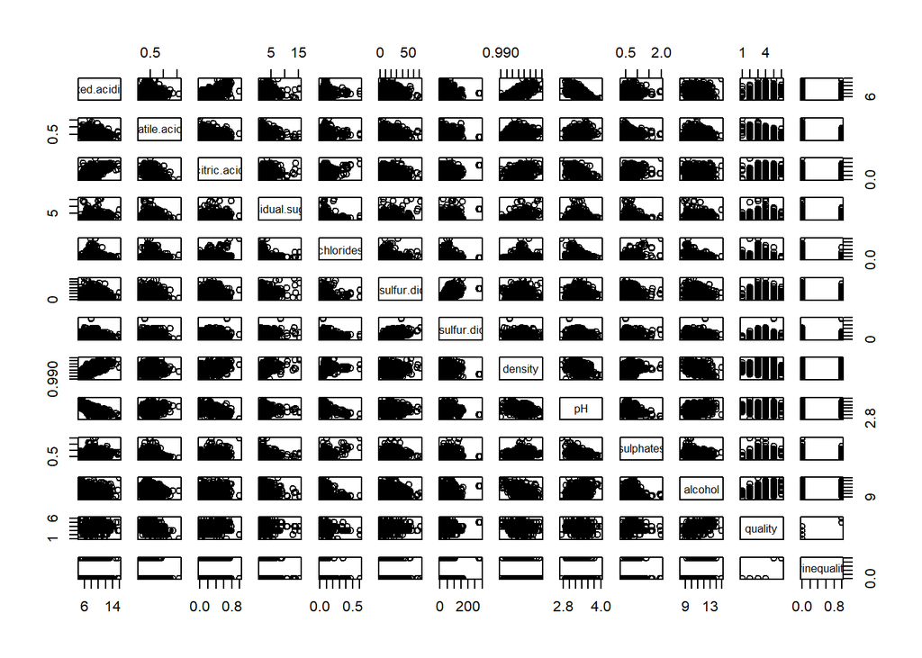

# Binning each variable and plotting it with the percentage of premium wine for that bucket.

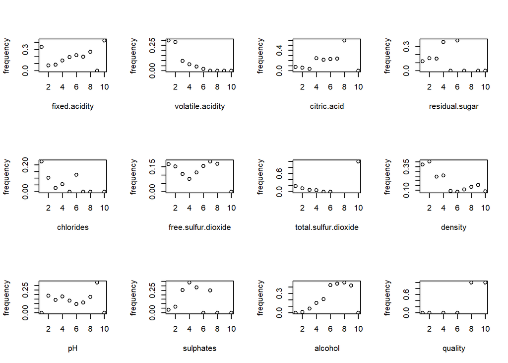

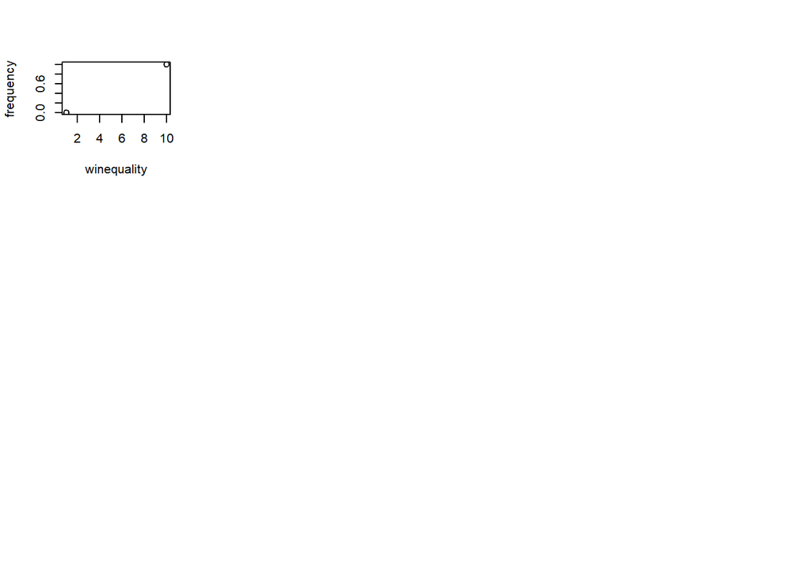

```r
winedatap$quality = as.numeric(winedatap$quality)
layout(matrix(c(1,2,3,4,5,6,7,8,9,10,11,12), ncol = 4, nrow = 3, byrow = TRUE))
for(i in colnames(winedatap)){
  plot.default(aggregate(winedatap$winequality, by = list(cut(winedatap[[i]], 10)), FUN = mean), xlab = i, ylab= "frequency")
  }
```

## Checking the relation between dependent varibale with independent varibales with the help of box plot

### Box Plot of Quality

[figure not shown]

```r
grid.arrange(ggplot(data = winedatap, aes(x = as.factor(quality) , y = fixed.acidity))+geom_boxplot(fill = "green") + xlab("quality") + ylab("fixed acidity (tartaric acid - g / dm^3)"),
             ggplot(data = winedatap, aes(x = as.factor(quality), y= volatile.acidity))+geom_boxplot(fill = "green") + xlab("quality")+ ylab("volatile acidity (acetic acid - g / dm^3)"),
             ggplot(data = winedatap, aes(x = as.factor(quality), y= citric.acid))+geom_boxplot(fill = "green") + xlab("quality")+ ylab(" citric acid (g / dm^3)"),
             ggplot(data = winedatap, aes(x = as.factor(quality), y= residual.sugar))+geom_boxplot(fill = "green") + xlab("quality")+ ylab("residual sugar (g / dm^3)"),
             ggplot(data = winedatap, aes(x = as.factor(quality), y= chlorides))+geom_boxplot(fill = "green")+ xlab("quality")+ ylab("chlorides (sodium chloride - g / dm^3"),
             ggplot(data = winedatap, aes(x = as.factor(quality), y= free.sulfur.dioxide))+geom_boxplot(fill = "green")+ xlab("quality")+ ylab(" free sulfur dioxide (mg / dm^3)"),
             ggplot(data = winedatap, aes(x = as.factor(quality), y= total.sulfur.dioxide))+geom_boxplot(fill = "green") + xlab("quality")+ ylab("total sulfur dioxide (mg / dm^3)"),
             ggplot(data = winedatap, aes(x = as.factor(quality), y= density))+geom_boxplot(fill = "green")+ xlab("quality")+ ylab("density (g / cm^3)"),
             ggplot(data = winedatap, aes(x = as.factor(quality), y= pH))+geom_boxplot(fill = "green")+ xlab("quality")+ ylab("pH"),
             ggplot(data = winedatap, aes(x = as.factor(quality), y= sulphates))+geom_boxplot(fill = "green")+ xlab("quality")+ ylab(" sulphates (potassium sulphate - g / dm3)"),
             ggplot(data = winedatap, aes(x = as.factor(quality), y= alcohol))+geom_boxplot(fill = "green")+ xlab("quality")+ ylab("alcohol (% by volume)"), ncol = 4)
```

### Boxplot of WineQuality

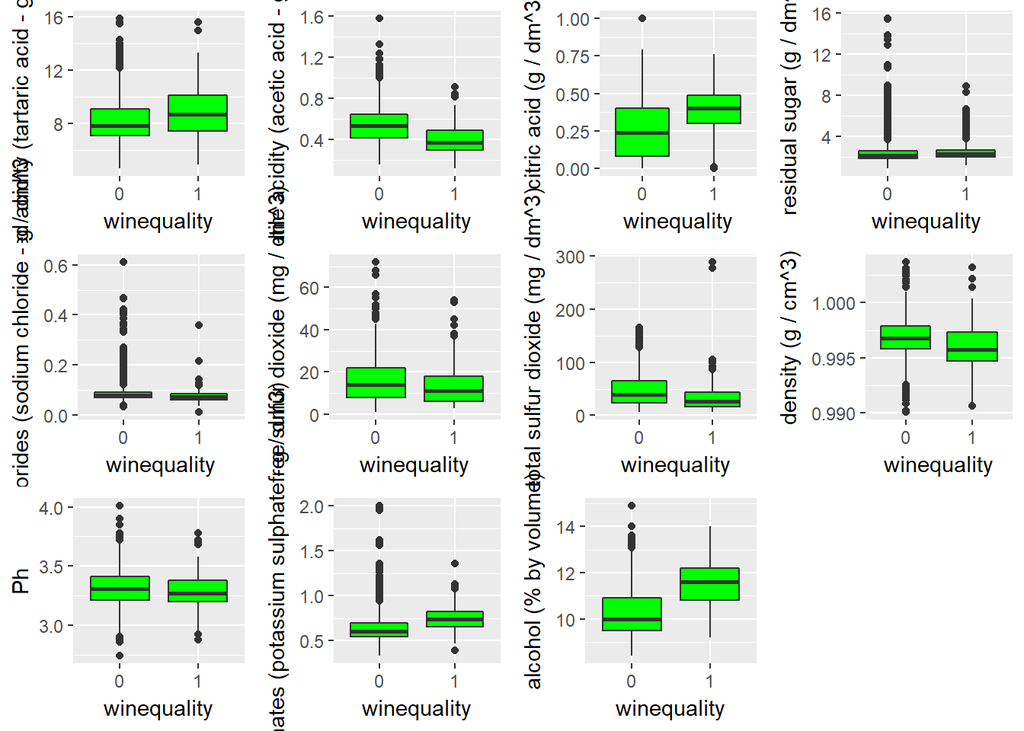

```r
grid.arrange(ggplot(data = winedatap, aes(x = as.factor(winequality) , y = fixed.acidity))+geom_boxplot(fill = "green") + xlab("winequality") + ylab("fixed acidity (tartaric acid - g / dm^3)"),
             ggplot(data = winedatap, aes(x = as.factor(winequality), y= volatile.acidity))+geom_boxplot(fill = "green") + xlab("winequality") + ylab("volatile acidity (acetic acid - g / dm^3)"),
             ggplot(data = winedatap, aes(x = as.factor(winequality), y= citric.acid))+geom_boxplot(fill = "green")+ xlab("winequality")+ ylab(" citric acid (g / dm^3)"),
             ggplot(data = winedatap, aes(x = as.factor(winequality), y= residual.sugar))+geom_boxplot(fill = "green")+ xlab("winequality")+ ylab("residual sugar (g / dm^3)"),
             ggplot(data = winedatap, aes(x = as.factor(winequality), y= chlorides))+geom_boxplot(fill = "green")+ xlab("winequality")+ ylab("chlorides (sodium chloride - g / dm^3"),
             ggplot(data = winedatap, aes(x = as.factor(winequality), y= free.sulfur.dioxide))+geom_boxplot(fill = "green")+ xlab("winequality") + ylab(" free sulfur dioxide (mg / dm^3)"),
             ggplot(data = winedatap, aes(x = as.factor(winequality), y= total.sulfur.dioxide))+geom_boxplot(fill = "green")+ xlab("winequality") + ylab("total sulfur dioxide (mg / dm^3)") ,
             ggplot(data = winedatap, aes(x = as.factor(winequality), y= density))+geom_boxplot(fill = "green")+ xlab("winequality") + ylab("density (g / cm^3)"),
             ggplot(data = winedatap, aes(x = as.factor(winequality), y= pH))+geom_boxplot(fill = "green")+ xlab("winequality") + ylab("Ph"),
             ggplot(data = winedatap, aes(x = as.factor(winequality), y= sulphates))+geom_boxplot(fill = "green")+ xlab("winequality") + ylab("sulphates (potassium sulphate - g / dm3)"),
             ggplot(data = winedatap, aes(x = as.factor(winequality), y= alcohol))+geom_boxplot(fill = "green")+ xlab("winequality") + ylab("alcohol (% by volume)"), ncol = 4)
```

# Bivariate Analysis

### Talk about some of the relationships you observed in this part of the How did the feature(s) of interest vary with other features in the dataset?

Sulphtes and alcohol has a positive correlation whereas volatile.acidity has negetive correlation with the decsion variable.

# Multivariate Plots Section

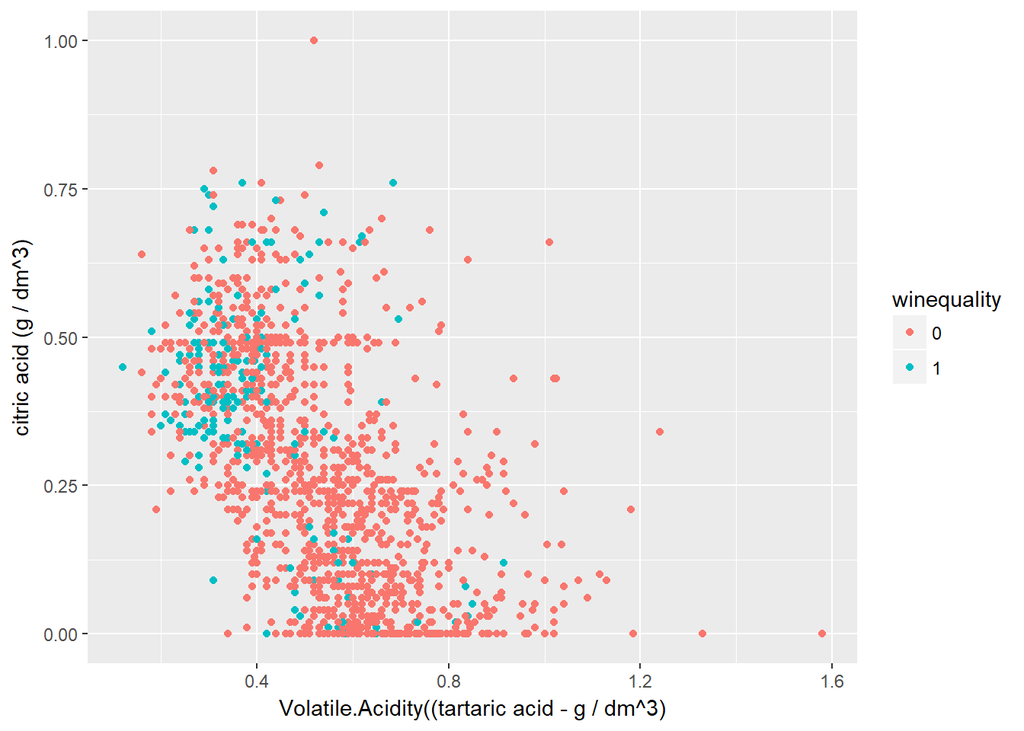

This above graph shows the relation between volatile acidity and citric acid. To attain the premium quality wine we can the value of volatilea acidity should have lower value, wehreas values of citic acid should be on the higher side.

[figure not shown]

```r
ggplot(winedatap, aes(x = volatile.acidity, y = sulphates,
                      color = winequality))+geom_point() +  xlab("sulphates (potassium sulphate - g / dm3)") + ylab("volatile acidity (acetic acid - g / dm^3)")
```

[figure not shown]

```r
ggplot(winedatap, aes(x = volatile.acidity, y = alcohol,
                      color = winequality))+geom_point() + xlab("alcohol (% by volume)") + ylab("volatile acidity (acetic acid - g / dm^3)")
```

This above graphs shows relationship between volatile acidity and alocohol, whcih depicts that there should be high alcohol content for remium wines and as usual volatile acidity values should be lower.

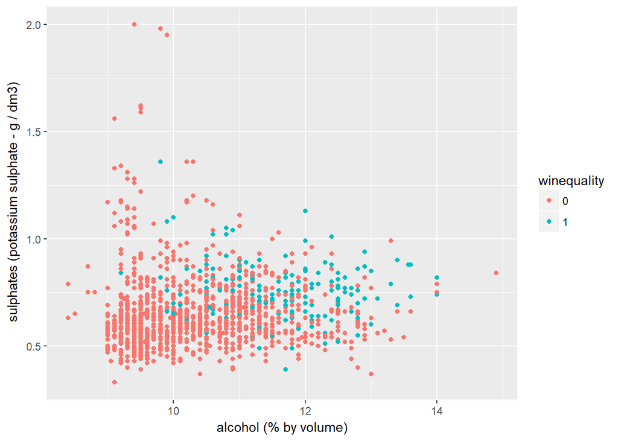

```r
ggplot(winedatap, aes(x = alcohol, y = sulphates,
                      color = winequality))+geom_point() + xlab("alcohol (% by volume)") + ylab(" sulphates (potassium sulphate - g / dm3)")
```

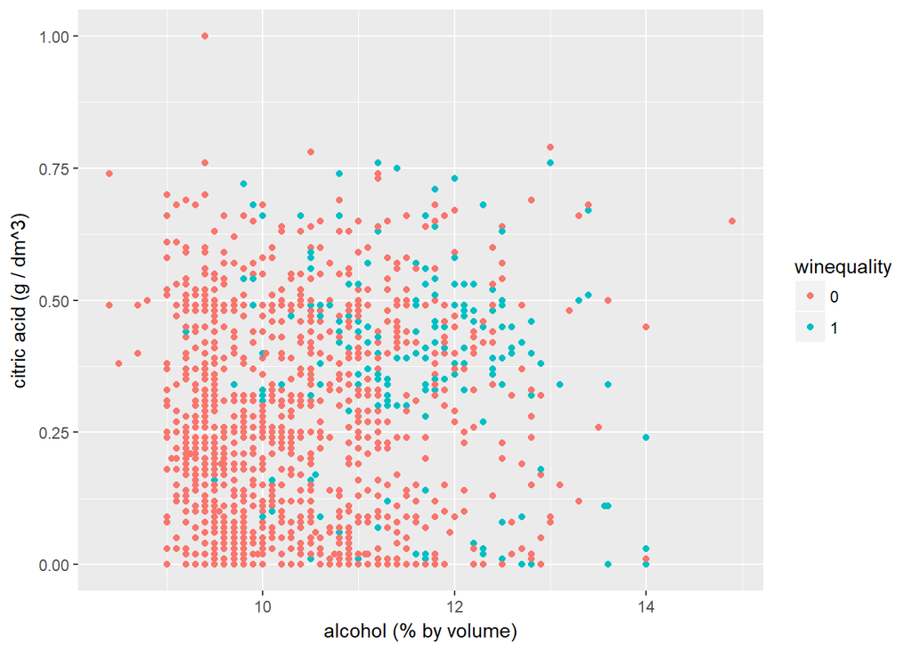

```r
ggplot(winedatap, aes(x = alcohol, y = citric.acid,
                      color = winequality))+geom_point() + xlab("alcohol (% by volume)") + ylab("citric acid (g / dm^3)")
```

The above graph shown is between alcohol and citric acid, which tells us that both alcohol and citric acid both should have higher value for creating the premium wine.

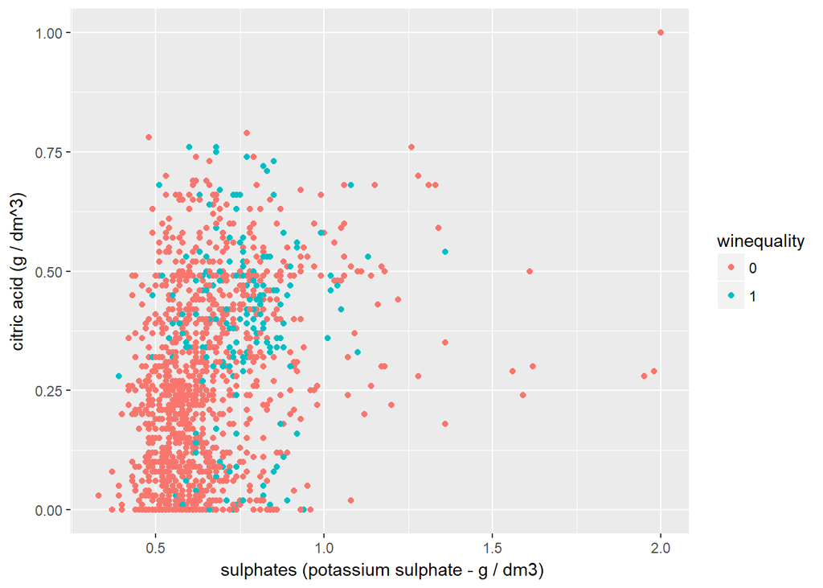

```r
ggplot(winedatap, aes(x = sulphates, y = citric.acid,
                      color = winequality))+geom_point() + xlab(" sulphates (potassium sulphate - g / dm3)") + ylab("citric acid (g / dm^3)")
```

# Multivariate Summary

*I have create six multivariate plots, between `Volatile.acidity`, `citric.acid`, `sulphates` and`alcohol`.* From these six graphs it is clear that to create premium wine we need lower concentration of `volatile acidity` but higher concentration of `alcohol`, `citric acid`and `sulphates`.

# Multivariate Analysis

### Talk about some of the relationships you observed in this part of the investigation. Were there features that strengthened each other in terms of looking at your feature(s) of interest?

Yes there are few relations which makes it clear to make premium wines.For Example if we talk about voaltile acidity and citric acid , we found that if higher citric acid and lower volatile acidity creates premium wines.

### Were there any interesting or surprising interactions between features?

No there is no as such surpising interactions between variables.

### OPTIONAL: Did you create any models with your dataset? Discuss the strengths and limitations of your model?

No i have not created any models fo this.

# Final Plots and Summary

### Plot One : Effect of alcohol on wine quality

[figure not shown]

```r
ggplot(data = winedatap, aes(as.factor(quality), alcohol, fill = winequality)) +
  geom_boxplot() +
  ggtitle('Alcohol Effect on Wine Quality') +
  xlab('Quality') +
  ylab('Alcohol (% volume)')
```

## Description One

As alcohol is highly correlated with the quality, it is better to see its pattern with varying rating. From the above plot, it clearly shows higher % of alcohol yields better wine.

### Plot Two : Effect of acids on wine quality

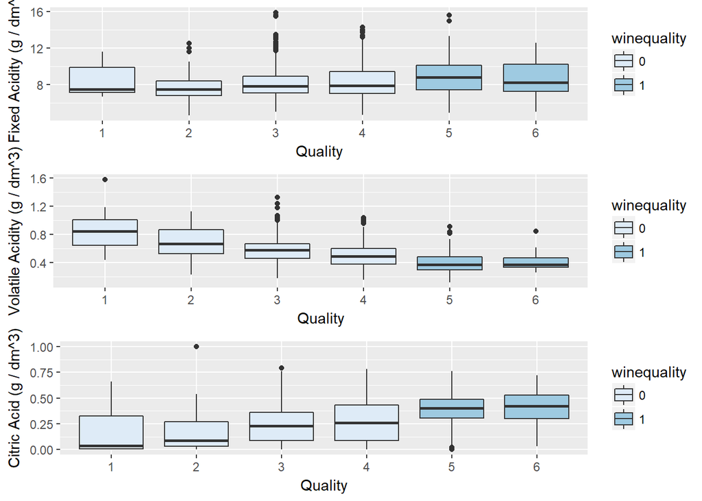

### Plot Three : Effect of citric acid and volatile acid on quality of wine.

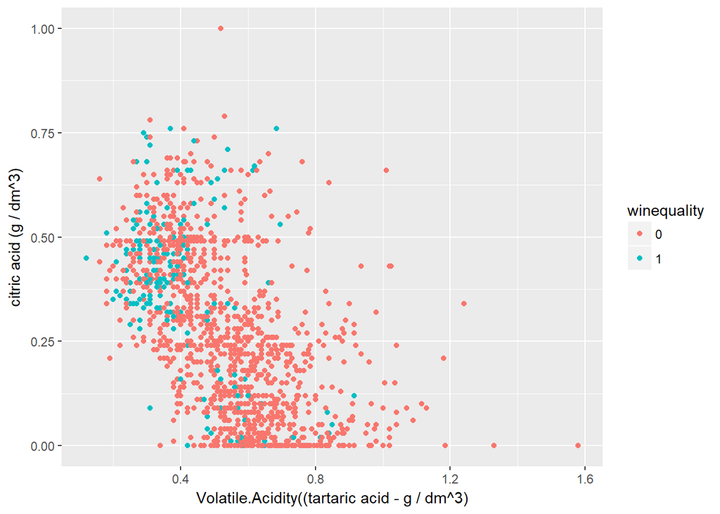

## Description Three

With voaltile acidity and citric acid , we found that if higher citric acid and lower volatile acidity creates premium wines.

# Reflection

Red Wine data contains 1599 data points for 13 variables. Basically it contains the quality of wine for diffirent values of these 13 variables. These varibales include, Fixed.acidity,Volatile.acidity,citric.acid,Residual.sugar ,Chlorides,Free.sulfur.oxide, Total.sulfur.dioxide,Density,Ph,Sulpahates,alcohol.

Then after that we checked the if there is any variables (leaving decision variable aside), are higly correlated to each other or not, and then checked the correlation of each variable with varibale if interest. From these action we found that there are four varibale which can actually predict the quality of wine.They are `Volatile.acidity`, `citric.acid`, `sulphates` and `alcohol`